# Project:No-show appointments

- Introduction
- Data Wrangling
- Exploratory Data Analysis
- Conclusions

## Introduction

> Analysing no show dataset which includes information about 100K medical appoints in brazil and focuses on whether the patients showed for there appointment or not. The dataset includes the dates and times of the appointment and also the gneder , scholarship , the neighborhood of the hospital and some diseases like Diabetes,Alcoholism,Handcap and Hipertension. the dependent variable here is the No-show colomn which speciefies whether the patient arrived or not. the questions will be all about the prediction of whether the patient will show or not.

```python
# Use this cell to set up import statements for all of the packages that you
#   plan to use.
# Remember to include a 'magic word' so that your visualizations are plotted
#   inline with the notebook. See this page for more:
#   http://ipython.readthedocs.io/en/stable/interactive/magics.html
import pandas as pd
import numpy as np
import matplotlib.pyplot as plt
%matplotlib inline
```

## Data Wrangling

### General Properties

```python
# Load your data and print out a few lines. Perform operations to inspect data
#   types and look for instances of missing or possibly errant data.
data=pd.read_csv('noshowappointments-kagglev2-may-2016.csv')
data.head()
```

|  | PatientId | AppointmentID | Gender | ScheduledDay | AppointmentDay | Age | Neighbourhood | Scholarship | Hipertension | Diabetes | Alcoholism | Handcap | SMS_received | No-show |
| --- | --- | --- | --- | --- | --- | --- | --- | --- | --- | --- | --- | --- | --- | --- |
| 0 | 2.987250e+13 | 5642903 | F | 2016-04-29T18:38:08Z | 2016-04-29T00:00:00Z | 62 | JARDIM DA PENHA | 0 | 1 | 0 | 0 | 0 | 0 | No |
| 1 | 5.589978e+14 | 5642503 | M | 2016-04-29T16:08:27Z | 2016-04-29T00:00:00Z | 56 | JARDIM DA PENHA | 0 | 0 | 0 | 0 | 0 | 0 | No |
| 2 | 4.262962e+12 | 5642549 | F | 2016-04-29T16:19:04Z | 2016-04-29T00:00:00Z | 62 | MATA DA PRAIA | 0 | 0 | 0 | 0 | 0 | 0 | No |
| 3 | 8.679512e+11 | 5642828 | F | 2016-04-29T17:29:31Z | 2016-04-29T00:00:00Z | 8 | PONTAL DE CAMBURI | 0 | 0 | 0 | 0 | 0 | 0 | No |
| 4 | 8.841186e+12 | 5642494 | F | 2016-04-29T16:07:23Z | 2016-04-29T00:00:00Z | 56 | JARDIM DA PENHA | 0 | 1 | 1 | 0 | 0 | 0 | No |

> so we have the patientid colomn and appointmnetID colomn are personal information so we won't be using them.

```python
data.info()
```

```
<class 'pandas.core.frame.DataFrame'>
RangeIndex: 110527 entries, 0 to 110526
Data columns (total 14 columns):
 #   Column          Non-Null Count   Dtype
---  ------          --------------   -----
 0   PatientId       110527 non-null  float64
 1   AppointmentID   110527 non-null  int64
 2   Gender          110527 non-null  object
 3   ScheduledDay    110527 non-null  object
 4   AppointmentDay  110527 non-null  object
 5   Age             110527 non-null  int64
 6   Neighbourhood   110527 non-null  object
 7   Scholarship     110527 non-null  int64
 8   Hipertension    110527 non-null  int64
 9   Diabetes        110527 non-null  int64
 10  Alcoholism      110527 non-null  int64
 11  Handcap         110527 non-null  int64
 12  SMS_received    110527 non-null  int64
 13  No-show         110527 non-null  object
dtypes: float64(1), int64(8), object(5)
memory usage: 11.8+ MB
```

> the data is pretty cleans there is no null values but the schudledDay and AppointmentDay are objects and we have to convert them to datatime so we can see the day year and time in the data set and we will be renaming the No-show column to No_show to be able to use.

### Data Cleaning

```python
# After discussing the structure of the data and any problems that need to be
#   cleaned, perform those cleaning steps in the second part of this section.
data.ScheduledDay = pd.to_datetime(data.ScheduledDay)
data.AppointmentDay = pd.to_datetime(data.AppointmentDay)
```

```python
data['ScheduledDay_day']=data['ScheduledDay'].dt.day
data['ScheduledDay_week']=data['ScheduledDay'].dt.isocalendar().week
data['ScheduledDay_month']=data['ScheduledDay'].dt.month
data['ScheduledDay_hour']=data['ScheduledDay'].dt.hour
```

```python
data.head()
```

|  | PatientId | AppointmentID | Gender | ScheduledDay | AppointmentDay | Age | Neighbourhood | Scholarship | Hipertension | Diabetes | Alcoholism | Handcap | SMS_received | No-show | ScheduledDay_day | ScheduledDay_week | ScheduledDay_month | ScheduledDay_hour |
| --- | --- | --- | --- | --- | --- | --- | --- | --- | --- | --- | --- | --- | --- | --- | --- | --- | --- | --- |
| 0 | 2.987250e+13 | 5642903 | F | 2016-04-29 18:38:08+00:00 | 2016-04-29 00:00:00+00:00 | 62 | JARDIM DA PENHA | 0 | 1 | 0 | 0 | 0 | 0 | No | 29 | 17 | 4 | 18 |
| 1 | 5.589978e+14 | 5642503 | M | 2016-04-29 16:08:27+00:00 | 2016-04-29 00:00:00+00:00 | 56 | JARDIM DA PENHA | 0 | 0 | 0 | 0 | 0 | 0 | No | 29 | 17 | 4 | 16 |
| 2 | 4.262962e+12 | 5642549 | F | 2016-04-29 16:19:04+00:00 | 2016-04-29 00:00:00+00:00 | 62 | MATA DA PRAIA | 0 | 0 | 0 | 0 | 0 | 0 | No | 29 | 17 | 4 | 16 |
| 3 | 8.679512e+11 | 5642828 | F | 2016-04-29 17:29:31+00:00 | 2016-04-29 00:00:00+00:00 | 8 | PONTAL DE CAMBURI | 0 | 0 | 0 | 0 | 0 | 0 | No | 29 | 17 | 4 | 17 |
| 4 | 8.841186e+12 | 5642494 | F | 2016-04-29 16:07:23+00:00 | 2016-04-29 00:00:00+00:00 | 56 | JARDIM DA PENHA | 0 | 1 | 1 | 0 | 0 | 0 | No | 29 | 17 | 4 | 16 |

```python
data['Age'].describe()
```

```
count    110527.000000
mean         37.088874
std          23.110205
min          -1.000000
25%          18.000000
50%          37.000000
75%          55.000000
max         115.000000
Name: Age, dtype: float64
```

> as we can see the min age is -1 which is not true so we have outliers that we need to deal with

```python
age=data[data['Age']<=-1]
age.shape[0]
```

```
1
```

> there is only one raw of Age with negative value so we will drope it

```python
data=data[data['Age']!=-1]
```

```python
data.rename(columns={'No-show':'No_show'},inplace=True)
```

## Exploratory Data Analysis

> appointmentid and patientid are personal informations so we won't be dealing with them

## No show column

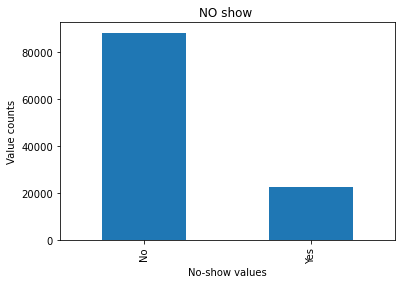

```python
data['No_show'].value_counts().plot(kind='bar',xlabel='No-show values', ylabel= 'Value counts',title= 'NO show ');
```

> so its clear that in this dataset the people who showed up are much greater than the who didn't

## is there any relation between the hour and the show up?

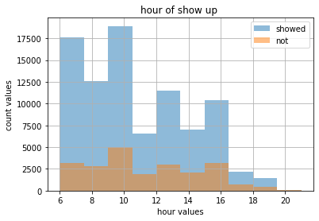

```python
showed = data.No_show =='No'
not_showed = data.No_show == 'Yes'

data.ScheduledDay_hour[showed].hist(alpha=0.5 , label='showed')
data.ScheduledDay_hour[not_showed].hist(alpha=0.5 , label='not')
plt.legend()
plt.title('hour of show up ')
plt.xlabel('hour values')
plt.ylabel('count values');
```

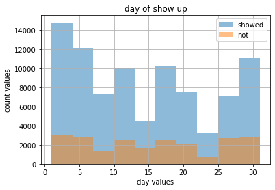

```python
data.ScheduledDay_day[showed].hist(alpha=0.5 , label='showed')
data.ScheduledDay_day[not_showed].hist(alpha=0.5 , label='not')
plt.legend()
plt.title('day of show up')
plt.xlabel('day values')
plt.ylabel('count values');
```

> noticed that there is no relation between them

## the relation between healthy people and non healthy people and show up

```python
healthy= data.query('Hipertension  == 0 & Diabetes == 0 & Alcoholism == 0 & Handcap == 0 ')
diseased = data.query('Hipertension  == 1 | Diabetes == 1 | Alcoholism == 1 | Handcap > 0 ')
```

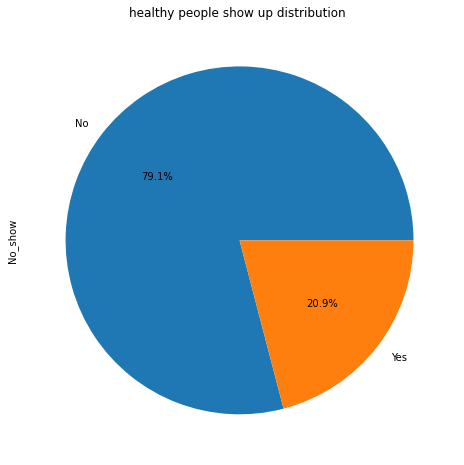

```python
healthy['No_show'].value_counts().plot(kind='pie', autopct='%1.1f%%', figsize=(8,8),title= 'healthy people show up distribution ');
```

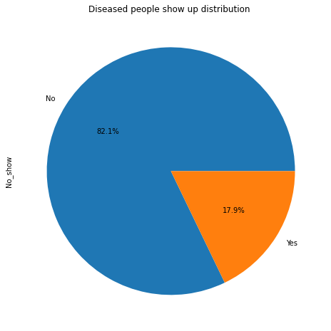

```python
diseased['No_show'].value_counts().plot(kind='pie', autopct='%1.1f%%', figsize=(8,8),title= 'Diseased people show up distribution ');
```

> noticed that there are slightly diffrence that the diseased people 82.1% showed up while the non diseased people 79.1% showed up

## Conclusions

#### introduction:

> in this part i imported the pandas,numby and matplotlib to the project and described the dataset and what the questions will be about in this project.

#### data wrangling:

> in this part i discovered the dataset the datatyes of each column and if there was any null values and then i cleaned the dataset by doing some changes to the dataset.

```python
from subprocess import call
call(['python', '-m', 'nbconvert', 'Investigate_a_Dataset.ipynb'])
```

```
1
```